# STAT 240

Week 10: More Text Data

Stat 240

## Today

- Recap: Clustering
- More analysis of Text Data
  - Strings and StringR
  - Regular expressions

# Brief Review of Clustering

## Clustering

- Unsupervised learning method - No response $Y$ to predict or use to evaluate our predictions
- Want to find groups of similar observations using numeric variables $X$
- Exploratory tool

## K-means clustering

- Iterative procedure to find clusters in data
- Choose the number of clusters, $k$ in advance
- Randomly assign each point to one of these clusters
- Run iterative procedure until stopping condition met

## K-means Procedure

Repeatedly:

- Compute the centroid of points in each cluster
- Move points to clusters based on which centroid is closest (Euclidean distance)

## Things to remember

- If cluster empty randomly make one data point the centroid
- How you place data in clusters initially will impact the clusters you get
- Run several clusters, pick the best one

## One Slide Summary - Taken from ISLR (book for 452)

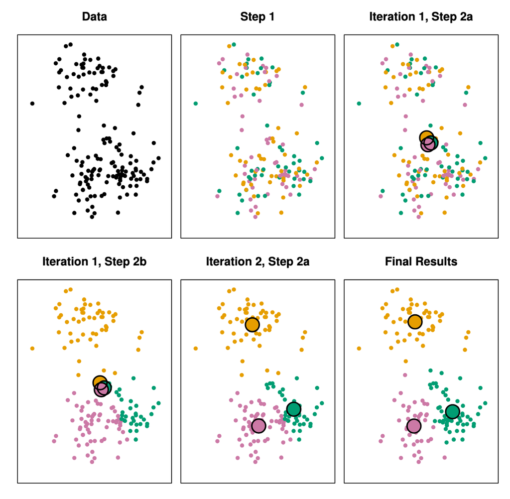

## Another clustering example

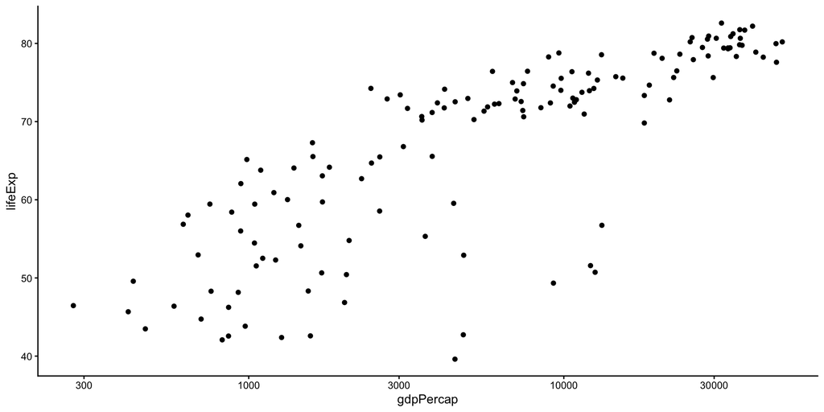

```r
ggplot(df, aes(x = gdpPercap, y = lifeExp)) +
  geom_point() +
  scale_x_log10() +
  theme_classic()
```

```r
set.seed(123)
k <- 3
km <- kmeans(df |> select(gdpPercap, lifeExp), centers = k, nstart = 20)
df$cluster <- as.factor(km$cluster)
```

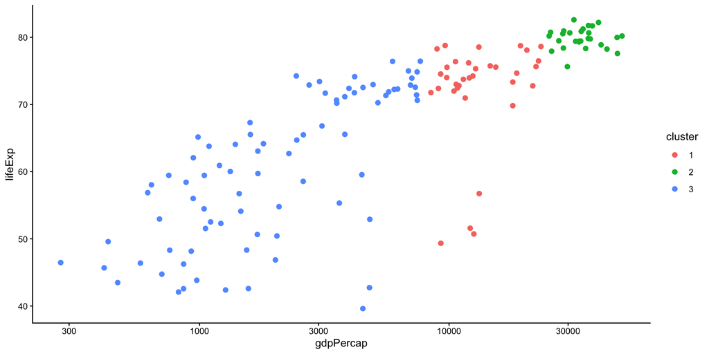

## Which countries are which

```r
clust_1 <- df[df$cluster == 1, "country"]
clust_1$country[1:10]
```

```
 [1] Argentina         Botswana          Brazil            Bulgaria
 [5] Chile             Costa Rica        Croatia           Cuba
 [9] Czech Republic    Equatorial Guinea
142 Levels: Afghanistan Albania Algeria Angola Argentina Australia ... Zimbabwe
```

```r
clust_2 <- df[df$cluster == 2, "country"]
clust_2$country[1:10]
```

```
 [1] Australia Austria   Bahrain   Belgium   Canada    Denmark   Finland
 [8] France    Germany   Greece
142 Levels: Afghanistan Albania Algeria Angola Argentina Australia ... Zimbabwe
```

```r
clust_3 <- df[df$cluster == 3, "country"]
clust_3$country[1:10]
```

```
 [1] Afghanistan            Albania                Algeria
 [4] Angola                 Bangladesh             Benin
 [7] Bolivia                Bosnia and Herzegovina Burkina Faso
[10] Burundi
142 Levels: Afghanistan Albania Algeria Angola Argentina Australia ... Zimbabwe
```

- K-means clustering seems to give reasonable results here
- Other issues which you will learn about in future classes (standardizing the data, etc)

# Strings

## Why we need strings

- Process and clean messy data, such as

```r
prices <- c("$12.50", "$7.00", "$105.99")
```

- What about if we wanted to get the sum of these prices?

```r
char_prices <- str_extract(prices, "\\d+\\.\\d+")
as.numeric(char_prices)
```

```
[1]  12.50   7.00 105.99
```

- Knowing some basic regular expressions very useful for things like this

## The stringr package

```r
library(stringr)
```

- The cleanest way to work with strings, previous methods were developed intermittently, harder to use
- The [corresponding chapter](https://r4ds.hadley.nz/strings.html) in R4DS is an excellent reference
- We will only cover a small selection of tools today
- First see some key baseR functions

## Some key functions

- The next few functions we will see are not specific to R, but rather R implementations of unix command line tools.
- These are useful to know about, if ever working with computing clusters, etc

## grep

**input**: a vector or list  
**output**: indices of elements with the pattern

```r
ExampleText <- c("1 - small thing to do",
                 "2 - 2 big things that we're doing",
                 "Some Small things that were done 4 free - 333",
                 "four Things that we've done")
grep("that", ExampleText)
```

```
[1] 2 3 4
```

```r
grep("small", ExampleText) #which elements have small (but not Small)
```

```
[1] 1
```

```r
grep("small", ExampleText, ignore.case = TRUE) #which elements have small or Small
```

```
[1] 1 3
```

```r
grep("small", ExampleText, ignore.case = TRUE, value = TRUE)
```

```
[1] "1 - small thing to do"
[2] "Some Small things that were done 4 free - 333"
```

```r
#which elements contain small, or Small, or smAll,...
```

```r
Example1 <- "1 - small thing to do"

grep("mall", Example1)# element in which it exists (there is only one element)
```

```
[1] 1
```

```r
grep("mdall", Example1)
```

```
integer(0)
```

## more on grep

- `grep` is not only an R function, can use it on the command line directly also
- I used this last week, to find a function written somewhere in one of many files

```r
grep("my_function", list.files("some_folder", full.names = TRUE), value = TRUE)
## Will return the files that contain "my_function"
```

## substr

**subset a string of text**  
**input**: a string of text  
**output**: the elements from start to stop.

```r
## Extract the letters between positions start and stop (inclusive)
substr(Example1, start = 6, stop = 15)
```

```
[1] "mall thing"
```

## gregexpr

**input**: a vector or list of text  
**output**: list showing text start position and pattern length

```r
ExampleText <- c("1 - small thing to do", "2 - 2 big things that we're doing",
                 "Some Small things that were done 4 free - 333",
                 "four Things that we've done")

gregexpr("thing", ExampleText)
```

```
[[1]]
[1] 11
attr(,"match.length")
[1] 5
attr(,"index.type")
[1] "chars"
attr(,"useBytes")
[1] TRUE

[[2]]
[1] 11
attr(,"match.length")
[1] 5
attr(,"index.type")
[1] "chars"
attr(,"useBytes")
[1] TRUE

[[3]]
[1] 12
attr(,"match.length")
[1] 5
attr(,"index.type")
[1] "chars"
attr(,"useBytes")
[1] TRUE

[[4]]
[1] -1
attr(,"match.length")
[1] -1
attr(,"index.type")
[1] "chars"
attr(,"useBytes")
[1] TRUE
```

```r
gregexpr("small", ExampleText)
```

```
[[1]]
[1] 5
attr(,"match.length")
[1] 5
attr(,"index.type")
[1] "chars"
attr(,"useBytes")
[1] TRUE

[[2]]
[1] -1
attr(,"match.length")
[1] -1
attr(,"index.type")
[1] "chars"
attr(,"useBytes")
[1] TRUE

[[3]]
[1] -1
attr(,"match.length")
[1] -1
attr(,"index.type")
[1] "chars"
attr(,"useBytes")
[1] TRUE

[[4]]
[1] -1
attr(,"match.length")
[1] -1
attr(,"index.type")
[1] "chars"
attr(,"useBytes")
[1] TRUE
```

```r
gregexpr("small", ExampleText, ignore.case = TRUE)
```

```
[[1]]
[1] 5
attr(,"match.length")
[1] 5
attr(,"index.type")
[1] "chars"
attr(,"useBytes")
[1] TRUE

[[2]]
[1] -1
attr(,"match.length")
[1] -1
attr(,"index.type")
[1] "chars"
attr(,"useBytes")
[1] TRUE

[[3]]
[1] 6
attr(,"match.length")
[1] 5
attr(,"index.type")
[1] "chars"
attr(,"useBytes")
[1] TRUE

[[4]]
[1] -1
attr(,"match.length")
[1] -1
attr(,"index.type")
[1] "chars"
attr(,"useBytes")
[1] TRUE
```

## gsub

**replace a pattern within a string**  
**input**: a list, vector, or string

```r
ExampleText <- c("1 - small thing to do",
                 "2 - 2 big things that we're doing",
                 "Some Small things that were done 4 free - 333",
                 "four Things that we've done")

gsub("thing", "stuff", ExampleText) # replace “thing” with “stuff”
```

```
[1] "1 - small stuff to do"
[2] "2 - 2 big stuffs that we're doing"
[3] "Some Small stuffs that were done 4 free - 333"
[4] "four Things that we've done"
```

```r
gsub("thing", "stuff", ExampleText, ignore.case = TRUE) # replace “thing”, “Thing”, “ThInG”, etc. with “stuff”
```

```
[1] "1 - small stuff to do"
[2] "2 - 2 big stuffs that we're doing"
[3] "Some Small stuffs that were done 4 free - 333"
[4] "four stuffs that we've done"
```

## Back to stringr

- Four key functions from `stringr`
  - Match a string and extract it: `str_extract` / `str_extract_all`
  - Detect a matching string `str_detect`
  - Replace one string with another `str_replace` / `str_replace_all`
  - Split a string on a substring `str_split`

## Key stringr Functions

- These functions work with both fixed/literal strings like `fish` as well as regular expressions like `f[aeiou]sh`
- We’ll see a bit more about regular expressions now
- These are always awkward to work with, good to know the basics but google is your friend

## Literal vs metacharacters

- Letters and numbers are **literal characters** - they match exactly

```r
fruit[1:5]
```

```
[1] "apple"       "apricot"     "avocado"     "banana"      "bell pepper"
```

```r
# Find all the fruits from fruit that contain "berry"
fruit[str_detect(string = fruit, pattern = "berry")]
```

```
 [1] "bilberry"    "blackberry"  "blueberry"   "boysenberry" "cloudberry"
 [6] "cranberry"   "elderberry"  "goji berry"  "gooseberry"  "huckleberry"
[11] "mulberry"    "raspberry"   "salal berry" "strawberry"
```

- Most punctuation characters like `., +, [ ], ?` are **metacharacters** that have special behaviour

```r
# Find all the fruits that contain an "a",
# followed by any three characters, followed by an "e"
fruit[str_detect(string = fruit, pattern = "a...e")]
```

```
[1] "apple"       "blackberry"  "mandarine"   "nectarine"   "pineapple"
[6] "pomegranate" "raspberry"   "salal berry"
```

## Escaping

What if you want to match a literal `.`? Need an escape, which tells the regexp to literally match metacharacters

- Like strings, regexps use the backslash, `\`, for escaping
- Since regexps are also strings, this makes things a bit tricky!
- E.g., to create the regular expression `\.`, use the string `\\.`
- E.g., to create the regular expression `\.`, use the string `\\.`

```r
mystrings <- c("abc", "a.c")
str_extract(mystrings, ".")
```

```
[1] "a" "a"
```

```r
str_extract(mystrings, "\\.")
```

```
[1] NA  "."
```

## Anchors

- Regexps match any part of a string. If you want to match at the start or end, use an anchor
  - Use `^` to match the start
  - Use `$` to match the end

```r
fruit[str_detect(fruit, "^a")]
```

```
[1] "apple"   "apricot" "avocado"
```

```r
fruit[str_detect(fruit, "a$")]
```

```
[1] "banana"    "cherimoya" "feijoa"    "guava"     "papaya"    "satsuma"
```

## More Anchors

- To force a match to only a full string, use both anchors. Notice the difference:

```r
fruit[str_detect(fruit, "apple")]
```

```
[1] "apple"     "pineapple"
```

```r
fruit[str_detect(fruit, "^apple$")]
```

```
[1] "apple"
```

- What about fruits which are **exactly** 5 letters long?

```r
fruit[str_detect(fruit, "^.....$")]
```

```
[1] "apple" "grape" "guava" "lemon" "mango" "olive" "peach"
```

## Character classes

- A character class or character set allows you to match any character in a set, and you can construct your own sets with `[ ]` and (if needed) special characters
- `[abc]` matches `"a", "b", "c"`

```r
# Fruits that start with "a", "b" or "c"
fruit[str_detect(fruit, "^[abc]")][1:8] #print 1st 8 only
```

```
[1] "apple"        "apricot"      "avocado"      "banana"       "bell pepper"
[6] "bilberry"     "blackberry"   "blackcurrant"
```

- `[^abc]` matches everything except `"a", "b", "c"`

```r
# Fruits that start with a letter other than "a", "b" or "c"
fruit[str_detect(fruit, "^[^abc]")][1:8] # 1st 8 only
```

```
[1] "damson"      "date"        "dragonfruit" "durian"      "eggplant"
[6] "elderberry"  "feijoa"      "fig"
```

- `-` indicates a range, e.g., `[a-z]` matches any lowercase letter and `[0-9]` matches any digit

```r
fruit[str_detect(fruit, "[w-z]")][1:8]
```

```
[1] "bilberry"     "blackberry"   "blueberry"    "boysenberry"  "canary melon"
[6] "cherimoya"    "cherry"       "cloudberry"
```

- `\` escapes special characters. `[\^\-\]]` matches `^`, `-`, or `]`

## Useful shortcuts

- `.` matches any character (except newline)
- `\d` matches any digit
- `\D` matches anything that isn’t a digit
- `\s` matches any whitespace (space, tab, newline, etc)
- `\S` matches anything that isn’t whitespace
- `\w` matches any “word” character (letters and numbers)
- `\W` matches any “non-word” character

## Adding `*` and `+` quantifiers to `.`

- The combinations `.*` and `.+` match multiple characters.
  - E.G., `f.*n` matches `f` followed by 0 or more characters, followed by `n`.
  - `f.+n` matches `f` followed by **1** or more characters, followed by `n`.

```r
mystrings <- c("fun", "flin flon", "flin flam", "fn")
pattern1 <- "f.*n"
pattern2 <- "f.+n"
str_extract(mystrings, pattern1)
```

```
[1] "fun"       "flin flon" "flin"      "fn"
```

```r
str_extract(mystrings, pattern2)
```

```
[1] "fun"       "flin flon" "flin"      NA
```

## “Greedy” matching with `*`

- The `*` quantifier matches the longest possible string.

```r
mystrings <- c("fun", "fun, fun, fun", "fn")
pattern1 <- "f.*n"
str_extract(mystrings, pattern1)
```

```
[1] "fun"           "fun, fun, fun" "fn"
```

## Numerical quantifiers

- Use `{n}` to require exactly `n` matches, `{n,}` to require n or more, `{,m}` at most m, and `{n,m}` between n and m.

```r
str_extract(mystrings, "f.{6}n")
```

```
[1] NA         "fun, fun" NA
```

```r
str_extract(mystrings, "f.{1,13}n")
```

```
[1] "fun"           "fun, fun, fun" NA
```

## Exercise

- What about fruits which are **exactly** 5 letters long?

```r
fruit[str_detect(fruit, "^.....$")]
```

```
[1] "apple" "grape" "guava" "lemon" "mango" "olive" "peach"
```

- Can we do this more easily now? (maybe we type too many `...`)

## Any character

Consider the regexp `p.n`

```r
mystrings <- c("pineapple", "apple", "pen")
str_detect(mystrings, "p.n")
```

```
[1]  TRUE FALSE  TRUE
```

```r
str_extract(mystrings,"p.n")
```

```
[1] "pin" NA    "pen"
```

```r
str_replace(mystrings,"p.n","PPP")
```

```
[1] "PPPeapple" "apple"     "PPP"
```

- Note that the replacement string in `str_replace` is literal:

```r
 str_replace(mystrings, "p.n", "p.n")
```

```
[1] "p.neapple" "apple"     "p.n"
```

## Digits

```r
mystrings <- c("$55.30", "$22.43")
str_extract(mystrings, "\\d") #Note that we need to "escape"
```

```
[1] "5" "2"
```

```r
str_extract_all(mystrings, "\\d")
```

```
[[1]]
[1] "5" "5" "3" "0"

[[2]]
[1] "2" "2" "4" "3"
```

## Whitespace

```r
mystrings <- c("it was the best of times",
               "it was the worst of times")
str_detect(mystrings, "\\s") #Note that we need to "escape"
```

```
[1] TRUE TRUE
```

```r
str_extract(mystrings, "\\s")
```

```
[1] " " " "
```

```r
str_extract(mystrings, "\\S")
```

```
[1] "i" "i"
```

## Words and non words

```r
mystrings <- c("My lunch cost", "$10.00")
str_extract_all(mystrings, "\\w") #Note that we need to "escape"
```

```
[[1]]
 [1] "M" "y" "l" "u" "n" "c" "h" "c" "o" "s" "t"

[[2]]
[1] "1" "0" "0" "0"
```

```r
str_extract_all(mystrings, "\\W")
```

```
[[1]]
[1] " " " "

[[2]]
[1] "$" "."
```

## Exercise

Last week we saw how many lines in the novel Emma contained the name `Emma`.

- Use the tools we have seen in this class to determine what proportion of lines in this text contain a word that includes the two letters `em`, followed by any other letter, followed by `a`. Are any of these not just `emma`? You should include both upper and lower case words!

```r
library(janeaustenr)
data("emma")
emma_lower <- str_to_lower(emma)
emma_lower[1:4]
```

```
[1] "emma"           ""               "by jane austen" ""
```

## Operators

- Using `|` in a regular expression is like the logical `OR`

```r
mystrings <- c("one fish", "two fish", "red fish", "blue fish")
str_detect(mystrings, "red|blue")
```

```
[1] FALSE FALSE  TRUE  TRUE
```

- Often use `|` with parentheses

```r
mystrings <- c("theater", "theatre")
str_extract(mystrings, "theat(er|re)")
```

```
[1] "theater" "theatre"
```

## Operator Precedence

- `ab+` is equivalent to `a(b+)` not `(ab)+`

```r
mystrings <- c("baby", "babble", "bababa")
str_extract(mystrings, "ab+")
```

```
[1] "ab"  "abb" "ab"
```

- `^a|b` is equivalent to `(^a)|(b$)`

```r
mystrings <- c(mystrings, "ability", "nab")
str_detect(mystrings, "^a|b$")
```

```
[1] FALSE FALSE FALSE  TRUE  TRUE
```

- When in doubt use parentheses!

## Grouping and capturing

- Parentheses also create **capturing groups** that allow you to use sub-components of a match
- For example, you can refer back to a capturing group with a back reference: `\1` refers to the match contained in the first parenthesis, `\2` in the second parenthesis, etc.
- Suppose you want to find fruits with a repeated pair of letters:

```r
fruit[str_detect(fruit, "(..)\\1")][1:4] #1st 4 only for space
```

```
[1] "banana"   "coconut"  "cucumber" "jujube"
```

- Or find words that start and end with the same pair of letters:

```r
words[str_detect(words, "^(..).*\\1$")][1:4] #1st 4 only for space
```

```
[1] "church"     "decide"     "photograph" "require"
```

## Exercise

- Use a regular expression to find any fruits where either:
  - The first two letters are repeated directly (e.g., coconut)
  - The fruit name contains two words

## Final Comment on Strings and Regular Expressions

> Some people, when confronted with a problem, think ‘I know, I’ll use regular expressions.’ Now they have two problems.

–Jamie Zawinski (Emacs forum)